# W_UP_01

Isabella Gonzalez

Spring 2021

The report structure should include five sections. see below

# Introduction

Create an Rstudio project in your shared space on rstudio.cloud. Using the dataset called pushups from the tigerstats package in R; answer the question posed by this null and alternate hypothesis in an html markdown document.

$H_0$: There is no difference between the average number of pushups of line vs skill players

$H_A$: The average number of pushups done by line players is statistically different than that of skill players.

# Methods

The response variable is number of pushups in two minutes, The explanatory variable is position: line or skill.

# Results

## Descriptive Results

### Graphical Descriptive Results

## Now with ggplot - first select the basic data

```r
basicCN <- ggplot(mydata,aes(x=position,y=pushups))
```

## Now add in boxplot

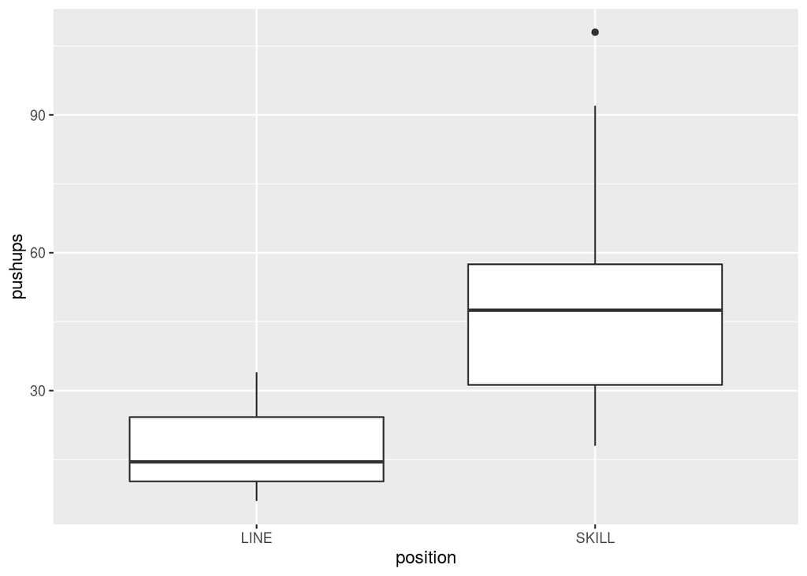

```r
basicCN + geom_boxplot()
```

### get fancy

```
## notch went outside hinges. Try setting notch=FALSE.
```

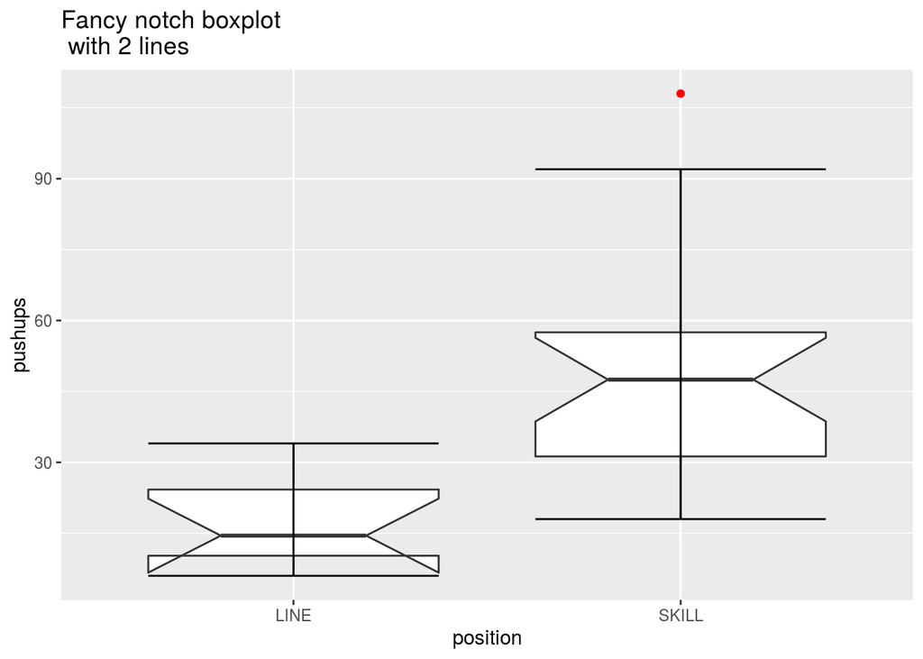

```r
basicCN + geom_boxplot(notch=TRUE,outlier.color = "red") + stat_boxplot(geom ='errorbar') + labs(title="Fancy notch boxplot \n with 2 lines")
```

This boxplot shows that skilled players seem to do more pushups in 2 minutes than line players.

### Numerical Descriptive Results

```r
favstats(pushups~position,data=mydata)
```

```
##   position min    Q1 median    Q3 max     mean        sd  n missing
## 1     LINE   6 10.25   14.5 24.25  34 17.12500  9.745878  8       0
## 2    SKILL  18 31.25   47.5 57.50 108 49.72727 23.036579 22       0
```

This numerical chart shows that Skilled players are doing a lot more pushups than those on the line.

## Inferential Results

```r
t.test(pushups~position,data=mydata)
```

```
##
##  Welch Two Sample t-test
##
## data:  pushups by position
## t = -5.4341, df = 27.079, p-value = 9.421e-06
## alternative hypothesis: true difference in means is not equal to 0
## 95 percent confidence interval:
##  -44.91068 -20.29387
## sample estimates:
##  mean in group LINE mean in group SKILL
##            17.12500            49.72727
```

The p-value is 0.000009,thus $H_0$ is highly unlikely; we reject the null hypothesis.

# Discussion and Conclusion

The original question was “Do players on the football team in line or sill positions do the same amount of pushups on average, within 2 minutes”

Both the numerical and graphical showed the skill position players did on average more pushups than 2 minutes than the line players.

The result is significant; too unlikely to have occurred by chance, we conclude that for George town players,the skilled positiion players do more pushups.